# A parser for raw and identification mass-spectrometry data

Bernd Fischer, Steffen Neumann, Laurent Gatto and Qiang Kou

15 April 2025

#### Package

mzR 2.42.0

# 1 Introduction

Most importantly, access to the data should be fast and memory efficient. This is made possible by allowing on-disk random file access, i.e. retrieving specific data of interest without having to sequentially browser the full content nor loading the entire data into memory.

The *mzR* package is in essence a collection of wrappers to the C++ code, and benefits from the C++ interface provided through the Rcpp package (Eddelbuettel and François 2011).

**IMPORTANT** New developers that need to access and manipulate raw mass spectrometry data are advised against using this infrastucture directly. They are invited to use the corresponding `MSnExp` (with *on disk* mode) from the*MSnbase* package instead. The latter supports reading multiple files at once and offers access to the spectra data (m/z and intensity) as well as all the spectra metadata using a coherent interface. The MSnbase infrastructure itself used the low level classes in mzR, thus offering fast and efficient access.

# 2 Mass spectrometry raw data

All the mass spectrometry file formats are organized similarly, where a set of metadata nodes about the run is followed by a list of spectra with the actual masses and intensities. In addition, each of these spectra has its own set of metadata, such as the retention time and acquisition parameters.

## 2.1 Spectral data access

Access to the spectral data is done via the `peaks` function. The return value is a list of two-column mass-to-charge and intensity matrices or a single matrix if one spectrum is queried.

## 2.2 Chromatogram access

Access to the chromatogram(s) is done using the `chromatogram` (or `chromatograms`) function, that return one (or a list of) data.frames. See `?chromatogram` for details. Chromatogram header information is available via the `chromatogramHeader` function that returns one (or a list of) data.frames. See `?chromatogramHeader` for details. This functionality is only available with the `pwiz` backend.

## 2.3 Identification result access

The main access to identification result is done via `psms`, `score` and `modifications`. `psms` and `score` will return the detailed information on each psm and scores. `modifications` will return the details on each modification found in peptide.

## 2.4 Metadata access

**Run metadata** is available via several functions such as `instrumentInfo()` or `runInfo()`. The individual fields can be accessed via e.g. `detector()` etc.

**Spectrum metadata** is available via `header()`, which will return a list (for single scans) or a dataframe with information such as the `basePeakMZ`, `peaksCount`, … or, for higher-order MS the `msLevel` and precursor information.

**Identification metadata**is available via `mzidInfo()`, which will return a list with information such as the `software`, `ModificationSearched`, `enzymes`, `SpectraSource` and other information for this identification result.

The availability of this metadata can not always be guaranteed, and depends on the MS software which converted the data.

# 3 Example

## 3.1 `mzXML`/`mzML` files

A short example sequence to read data from a mass spectrometer. First open the file.

```r
library(mzR)
library(msdata)

mzxml <- system.file("threonine/threonine_i2_e35_pH_tree.mzXML",
                     package = "msdata")
aa <- openMSfile(mzxml)
```

We can obtain different kind of header information.

```r
runInfo(aa)
```

```
## $scanCount
## [1] 55
##
## $lowMz
## [1] 50.0036
##
## $highMz
## [1] 298.673
##
## $dStartTime
## [1] 0.3485
##
## $dEndTime
## [1] 390.027
##
## $msLevels
## [1] 1 2 3 4
##
## $startTimeStamp
## [1] NA
```

```r
instrumentInfo(aa)
```

```
## $manufacturer
## [1] "Thermo Scientific"
##
## $model
## [1] "LTQ Orbitrap"
##
## $ionisation
## [1] "electrospray ionization"
##
## $analyzer
## [1] "fourier transform ion cyclotron resonance mass spectrometer"
##
## $detector
## [1] "unknown"
##
## $software
## [1] "Xcalibur software 2.2 SP1"
##
## $sample
## [1] ""
##
## $source
## [1] ""
```

```r
header(aa,1)
```

```
##   seqNum acquisitionNum msLevel polarity peaksCount totIonCurrent retentionTime
## 1      1              1       1        1        684     341427000        0.3485
##   basePeakMZ basePeakIntensity collisionEnergy ionisationEnergy   lowMZ  highMZ
## 1    120.066         211860000              NA                0 50.3254 298.673
##   precursorScanNum precursorMZ precursorCharge precursorIntensity mergedScan
## 1               NA          NA              NA                 NA         NA
##   mergedResultScanNum mergedResultStartScanNum mergedResultEndScanNum
## 1                  NA                       NA                     NA
##   injectionTime filterString                                 spectrumId
## 1             0         <NA> controllerType=0 controllerNumber=1 scan=1
##   centroided ionMobilityDriftTime isolationWindowTargetMZ
## 1       TRUE                   NA                      NA
##   isolationWindowLowerOffset isolationWindowUpperOffset scanWindowLowerLimit
## 1                         NA                         NA              50.3254
##   scanWindowUpperLimit electronBeamEnergy
## 1              298.673                 NA
```

Read a single spectrum from the file.

```r
pl <- peaks(aa,10)
peaksCount(aa,10)
```

```
## [1] 317
```

```r
head(pl)
```

```
##            mz intensity
## [1,] 50.08176  6984.858
## [2,] 50.62267  7719.419
## [3,] 50.70530  7185.290
## [4,] 50.73298  7509.140
## [5,] 50.83848  9366.624
## [6,] 50.88303  8012.808
```

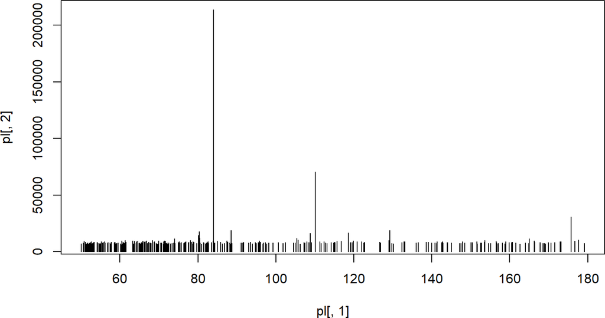

```r
plot(pl[,1], pl[,2], type="h", lwd=1)
```

One should always close the file when not needed any more. This will release the memory of cached content.

```r
close(aa)
```